# Wearable Device Modelling Project

2023-11-27

```r
library(ggplot2)
library(tidyr)
library(stats)
library(glmnet)
library(randomForest)
library(caret)
library(gbm)
library(e1071)
library(caret)
library(randomForest)
library(boot)
library(reshape2)
set.seed(1)
```

## Exploratory Data Analysis

```r
file_path <- "full/path/to/your/data/raw/aw_fb_data.csv"

# Check file permissions
file_permission <- file.access(file_path)

if (file_permission == 0) {
  print("No access to the file.")
} else if (file_permission == 1) {
  print("File can be executed.")
} else if (file_permission == 2) {
  print("File can be written.")
} else if (file_permission == 4) {
  print("File can be read.")
} else {
  print("Unknown permission status.")
}
```

```
## [1] "Unknown permission status."
```

```r
aw_fb_data <- read.csv("data/raw/aw_fb_data.csv")
head(aw_fb_data)
```

```
##   X X1 age gender height weight    steps hear_rate   calories    distance
## 1 1  1  20      1    168   65.4 10.77143  78.53130  0.3445329 0.008326857
## 2 2  2  20      1    168   65.4 11.47532  78.45339  3.2876255 0.008896346
## 3 3  3  20      1    168   65.4 12.17922  78.54083  9.4840000 0.009465835
## 4 4  4  20      1    168   65.4 12.88312  78.62826 10.1545556 0.010035325
## 5 5  5  20      1    168   65.4 13.58701  78.71569 10.8251111 0.010604814
## 6 6  6  20      1    168   65.4 14.29091  78.80313 11.4956667 0.011174303
##   entropy_heart entropy_setps resting_heart corr_heart_steps norm_heart
## 1      6.221612      6.116349            59        1.0000000   19.53130
## 2      6.221612      6.116349            59        1.0000000   19.45339
## 3      6.221612      6.116349            59        1.0000000   19.54083
## 4      6.221612      6.116349            59        1.0000000   19.62826
## 5      6.221612      6.116349            59        0.9828157   19.71569
## 6      6.221612      6.116349            59        1.0000000   19.80313
##   intensity_karvonen sd_norm_heart steps_times_distance      device activity
## 1          0.1385199      1.000000           0.08969215 apple watch    Lying
## 2          0.1379673      1.000000           0.10208846 apple watch    Lying
## 3          0.1385874      1.000000           0.11528650 apple watch    Lying
## 4          0.1392075      1.000000           0.12928626 apple watch    Lying
## 5          0.1398276      0.241567           0.14408774 apple watch    Lying
## 6          0.1404477      0.264722           0.15969095 apple watch  Sitting
```

```r
summary(aw_fb_data)
```

```
##        X              X1              age            gender
##  Min.   :   1   Min.   :   1.0   Min.   :18.00   Min.   :0.0000
##  1st Qu.:1567   1st Qu.: 789.8   1st Qu.:23.00   1st Qu.:0.0000
##  Median :3132   Median :1720.0   Median :28.00   Median :0.0000
##  Mean   :3132   Mean   :1771.1   Mean   :29.16   Mean   :0.4765
##  3rd Qu.:4698   3rd Qu.:2759.2   3rd Qu.:33.00   3rd Qu.:1.0000
##  Max.   :6264   Max.   :3670.0   Max.   :56.00   Max.   :1.0000
##      height          weight           steps           hear_rate
##  Min.   :143.0   Min.   : 43.00   Min.   :   1.00   Min.   :  2.222
##  1st Qu.:160.0   1st Qu.: 60.00   1st Qu.:   5.16   1st Qu.: 75.598
##  Median :168.0   Median : 68.00   Median :  10.09   Median : 77.268
##  Mean   :169.7   Mean   : 69.61   Mean   : 109.56   Mean   : 86.142
##  3rd Qu.:180.0   3rd Qu.: 77.30   3rd Qu.: 105.85   3rd Qu.: 95.669
##  Max.   :191.0   Max.   :115.00   Max.   :1714.00   Max.   :194.333
##     calories           distance        entropy_heart   entropy_setps
##  Min.   : 0.05627   Min.   :  0.0004   Min.   :0.000   Min.   :0.000
##  1st Qu.: 0.73587   1st Qu.:  0.0191   1st Qu.:6.109   1st Qu.:5.909
##  Median : 4.00000   Median :  0.1817   Median :6.190   Median :6.157
##  Mean   :19.47182   Mean   : 13.8326   Mean   :6.030   Mean   :5.740
##  3rd Qu.:20.50000   3rd Qu.: 15.6972   3rd Qu.:6.248   3rd Qu.:6.248
##  Max.   :97.50000   Max.   :335.0000   Max.   :6.476   Max.   :6.476
##  resting_heart    corr_heart_steps    norm_heart      intensity_karvonen
##  Min.   :  3.00   Min.   :-1.0000   Min.   :-76.000   Min.   :-2.714286
##  1st Qu.: 58.13   1st Qu.:-0.4673   1st Qu.:  1.149   1st Qu.: 0.009819
##  Median : 75.00   Median : 0.6658   Median :  9.820   Median : 0.079529
##  Mean   : 65.87   Mean   : 0.3064   Mean   : 20.272   Mean   : 0.155479
##  3rd Qu.: 76.14   3rd Qu.: 1.0000   3rd Qu.: 27.077   3rd Qu.: 0.211868
##  Max.   :155.00   Max.   : 1.0000   Max.   :156.319   Max.   : 1.297980
##  sd_norm_heart     steps_times_distance    device            activity
##  Min.   : 0.0000   Min.   :    0.00     Length:6264        Length:6264
##  1st Qu.: 0.2647   1st Qu.:    0.66     Class :character   Class :character
##  Median : 2.8935   Median :   13.37     Mode  :character   Mode  :character
##  Mean   : 8.1108   Mean   :  590.04
##  3rd Qu.: 9.6797   3rd Qu.:   93.73
##  Max.   :74.4579   Max.   :51520.00
```

```r
names(aw_fb_data)
```

```
##  [1] "X"                    "X1"                   "age"
##  [4] "gender"               "height"               "weight"
##  [7] "steps"                "hear_rate"            "calories"
## [10] "distance"             "entropy_heart"        "entropy_setps"
## [13] "resting_heart"        "corr_heart_steps"     "norm_heart"
## [16] "intensity_karvonen"   "sd_norm_heart"        "steps_times_distance"
## [19] "device"               "activity"
```

```r
#Cleaning the data
columns_to_drop <- c("X1", "X", "device", "entropy_heart", "entropy_setps", "corr_heart_steps", "norm_heart", "sd_norm_heart")
aw_fb_data <- aw_fb_data[, !(names(aw_fb_data) %in% columns_to_drop)]
colnames(aw_fb_data)[colnames(aw_fb_data) == "hear_rate"] <- "heart_rate"
```

## Including Plots

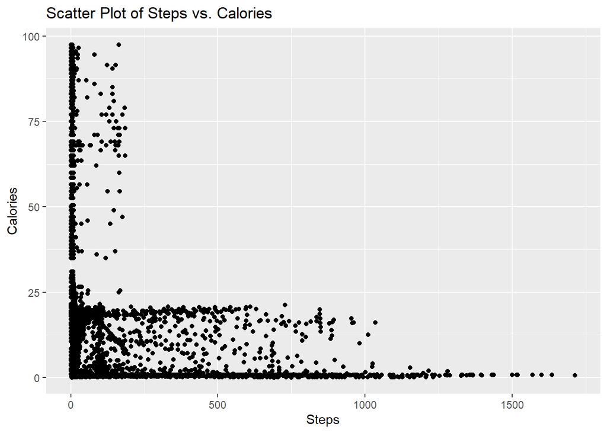

```r
# Basic scatter plot to visualize the relationship between 'steps' and 'calories'
ggplot(aw_fb_data, aes(x = steps, y = calories)) + geom_point() + labs(title = "Scatter Plot of Steps vs. Calories", x = "Steps", y = "Calories")
```

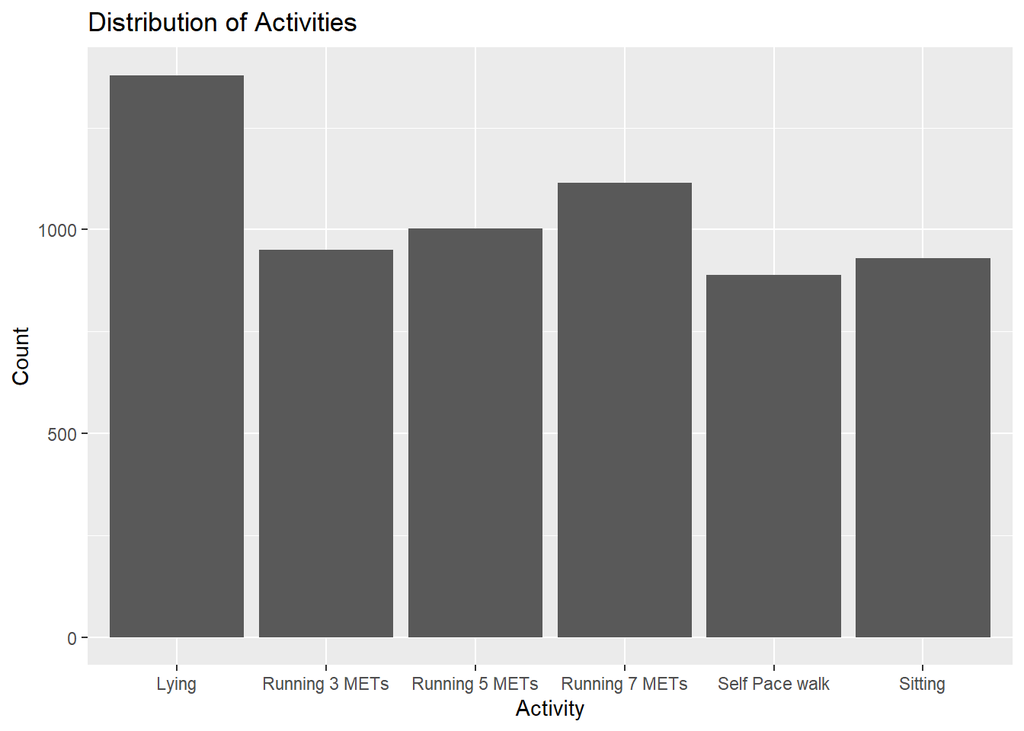

```r
# Barplot for Activity Distribution
ggplot(aw_fb_data, aes(x = activity)) +
  geom_bar() +
  labs(title = "Distribution of Activities", x = "Activity", y = "Count")
```

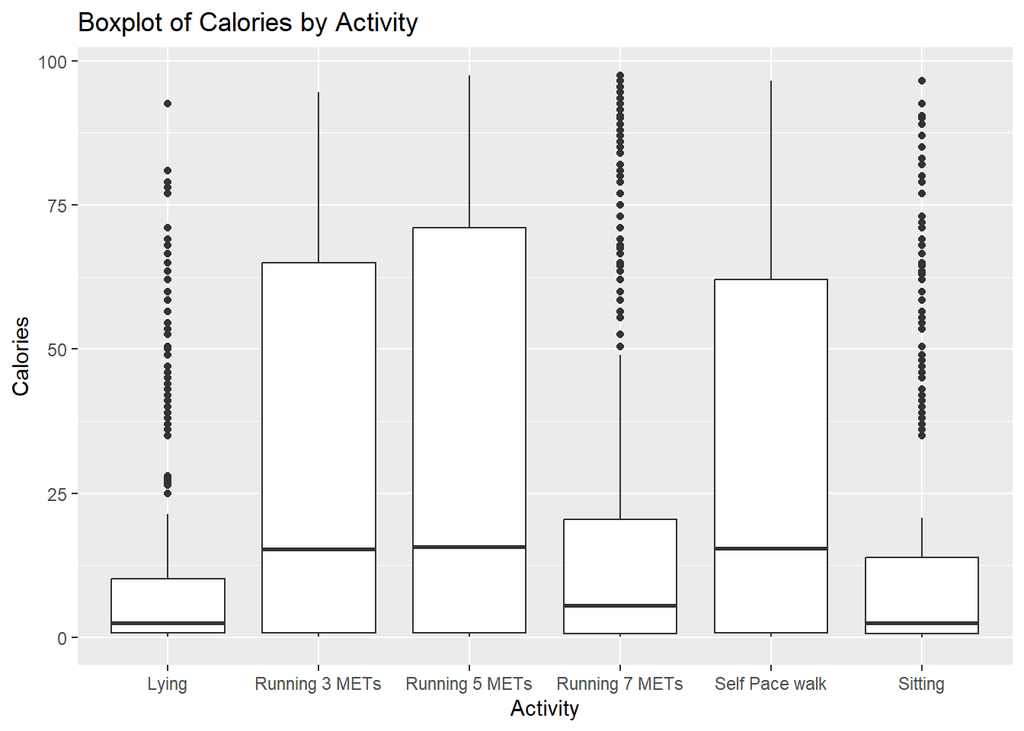

```r
# Boxplot to compare calories across different activities
ggplot(aw_fb_data, aes(x = activity, y = calories)) + geom_boxplot() + labs(title = "Boxplot of Calories by Activity", x = "Activity", y = "Calories")
```

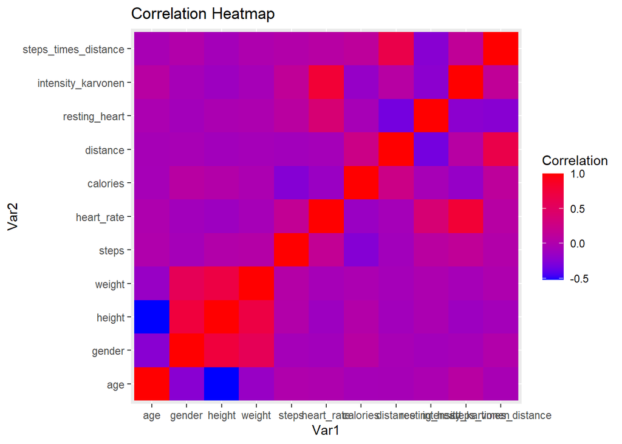

```r
# Selecting numerical variables for correlation heatmap
cor_variables <- c("age", "gender", "height", "weight", "steps", "heart_rate", "calories", "distance", "resting_heart", "intensity_karvonen", "steps_times_distance")

# Reshape the data for the correlation heatmap
cor_matrix <- cor(aw_fb_data[, cor_variables])
cor_matrix_long <- as.data.frame(as.table(cor_matrix))
colnames(cor_matrix_long) <- c("Var1", "Var2", "Correlation")

# Plot the correlation heatmap
library(ggplot2)
ggplot(data = cor_matrix_long, aes(x = Var1, y = Var2, fill = Correlation)) +
  geom_tile() +
  scale_fill_gradient(low = "blue", high = "red") +
  labs(title = "Correlation Heatmap")
```

```r
### cleaning the data
columns_to_drop <- c("activity")
aw_fb_data_reg <- aw_fb_data[, !(names(aw_fb_data) %in% columns_to_drop)]

### checking for null values
any_na_values <- any(is.na(aw_fb_data_reg))
print(any_na_values)
```

```
## [1] FALSE
```

## Principal Component Analysis

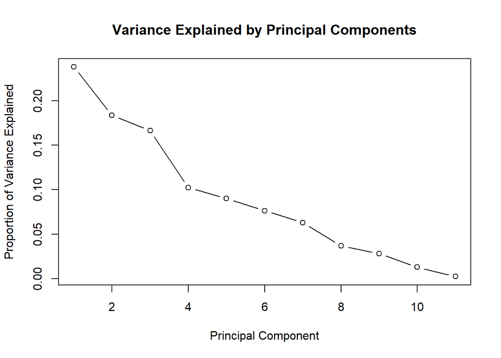

```r
# Remove constant columns
constant_cols <- sapply(aw_fb_data, function(x) length(unique(x))) == 1
data_pca <- aw_fb_data[, !constant_cols]

# Handle missing values (imputation or removal)
# For imputation, you can use packages like 'mice', 'missForest', or 'imputeTS'
# Perform appropriate handling of missing values in 'data_pca'

# Perform PCA after handling missing values and removing constant columns
pca_result <- prcomp(data_pca[, -which(names(data_pca) == "activity")], scale. = TRUE, center = TRUE)

# Accessing loadings and scores
loadings <- pca_result$rotation # Loadings
scores <- pca_result$x # Scores

# Calculate proportion of variance explained by each PC
prop_var <- (pca_result$sdev^2) / sum(pca_result$sdev^2)

# Create a cumulative proportion of variance explained
cumulative_prop_var <- cumsum(prop_var)

# Plotting variance explained by each principal component
plot(prop_var, type = 'b', xlab = "Principal Component", ylab = "Proportion of Variance Explained",
     main = "Variance Explained by Principal Components")
```

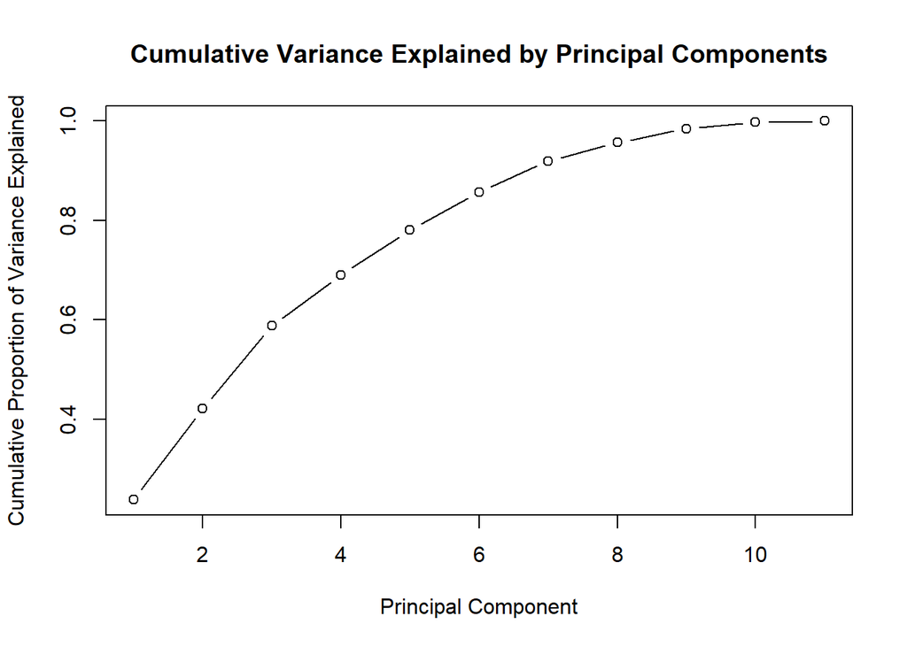

```r
# Plotting cumulative proportion of variance explained
plot(cumulative_prop_var, type = 'b', xlab = "Principal Component", ylab = "Cumulative Proportion of Variance Explained",
     main = "Cumulative Variance Explained by Principal Components")
```

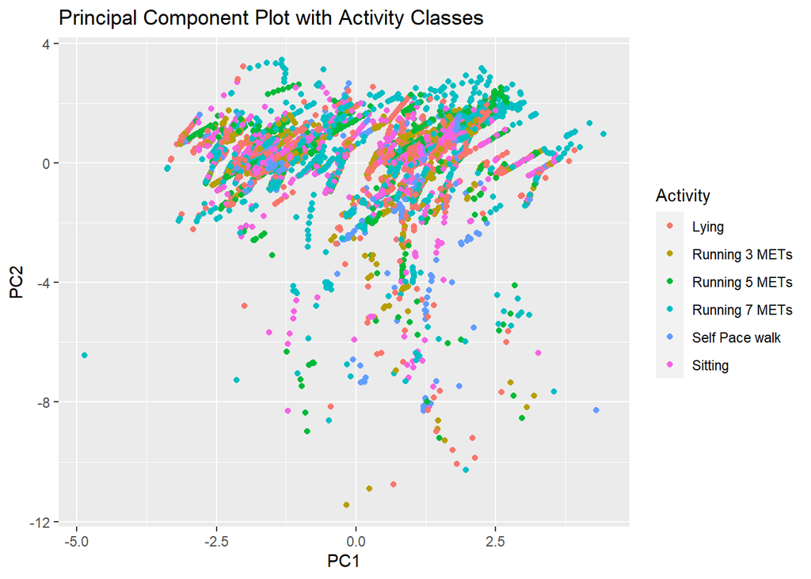

```r
# Accessing specific components (e.g., PC1 and PC2)
pc1 <- scores[, 1] # PC1 scores
pc2 <- scores[, 2] # PC2 scores

# Create a data frame with PC1, PC2, and activity labels
pc_df <- data.frame(PC1 = pc1, PC2 = pc2, Activity = data_pca$activity)

# Plotting PC1 vs PC2 and coloring points by 'activity' with class labels highlighted
library(ggplot2)

ggplot(pc_df, aes(x = PC1, y = PC2, color = Activity)) +
  geom_point() +
  labs(x = "PC1", y = "PC2", title = "Principal Component Plot with Activity Classes")
```

```r
# split into test and train
index <- sample(1:nrow(aw_fb_data_reg), 0.7 * nrow(aw_fb_data_reg))

train_data <- aw_fb_data_reg[index, ]
test_data <- aw_fb_data_reg[-index, ]
```

# 1. Regression

## Multiple Linear Regression

```r
# Number of folds for cross-validation
num_folds <- 5

# Create indices for cross-validation
cv_indices <- sample(1:num_folds, size = nrow(train_data), replace = TRUE)

# Define the model formula
formula <- calories ~ age + gender + height + weight + steps + heart_rate + distance + resting_heart + intensity_karvonen + steps_times_distance

# Perform cross-validation using cv.glm()
cv_results <- cv.glm(train_data, glm(formula, data = train_data), K = num_folds)
cv_mse <- cv_results$delta  # Extract MSE values from cross-validation

# Average MSE across folds
average_cv_mse <- mean(cv_mse)
cat("Average Cross-Validated MSE:", average_cv_mse, "\n")
```

```
## Average Cross-Validated MSE: 646.4974
```

```r
# Fit the model on the entire training set
final_lm.fit <- glm(formula, data = train_data)

# Make predictions on the test set
test_predictions <- predict(final_lm.fit, newdata = test_data)

# Calculate test accuracy
test_accuracy <- mean((test_data$calories - test_predictions)^2)
cat("Test Accuracy (MSE) on Test Data:", test_accuracy, "\n")
```

```
## Test Accuracy (MSE) on Test Data: 623.4597
```

```r
# Summary of the final model
summary(final_lm.fit)
```

```
##
## Call:
## glm(formula = formula, data = train_data)
##
## Coefficients:
##                        Estimate Std. Error t value Pr(>|t|)
## (Intercept)           1.322e+01  1.328e+01   0.995 0.319568
## age                  -9.775e-03  5.736e-02  -0.170 0.864697
## gender                4.423e+00  1.207e+00   3.663 0.000252 ***
## height                9.012e-02  8.049e-02   1.120 0.262940
## weight               -1.659e-01  4.236e-02  -3.916 9.16e-05 ***
## steps                -2.487e-02  1.809e-03 -13.746  < 2e-16 ***
## heart_rate            2.362e-01  5.010e-02   4.715 2.50e-06 ***
## distance              1.447e-01  1.146e-02  12.632  < 2e-16 ***
## resting_heart        -1.722e-01  4.524e-02  -3.805 0.000143 ***
## intensity_karvonen   -4.751e+01  6.358e+00  -7.472 9.52e-14 ***
## steps_times_distance -1.724e-04  1.263e-04  -1.365 0.172257
## ---
## Signif. codes:  0 '***' 0.001 '**' 0.01 '*' 0.05 '.' 0.1 ' ' 1
##
## (Dispersion parameter for gaussian family taken to be 635.3854)
##
##     Null deviance: 3274329  on 4383  degrees of freedom
## Residual deviance: 2778540  on 4373  degrees of freedom
## AIC: 40750
##
## Number of Fisher Scoring iterations: 2
```

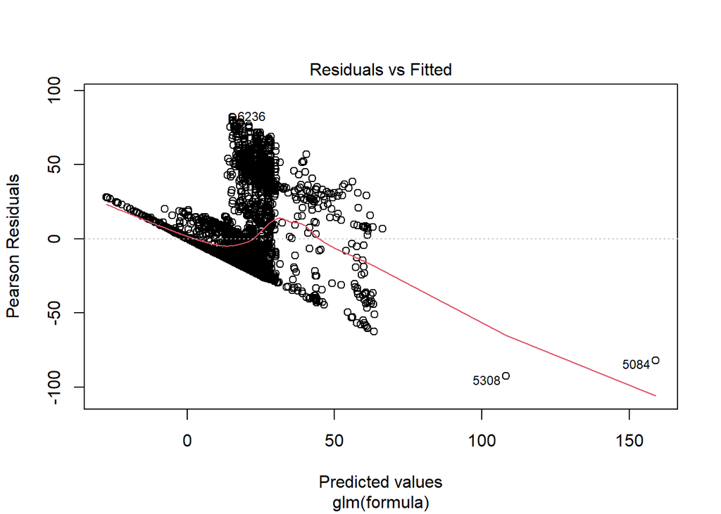

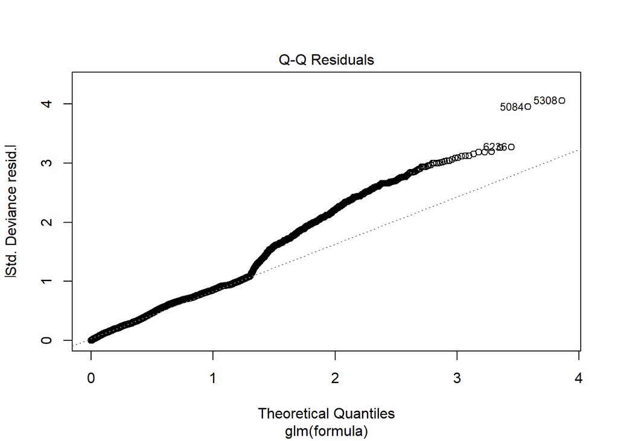

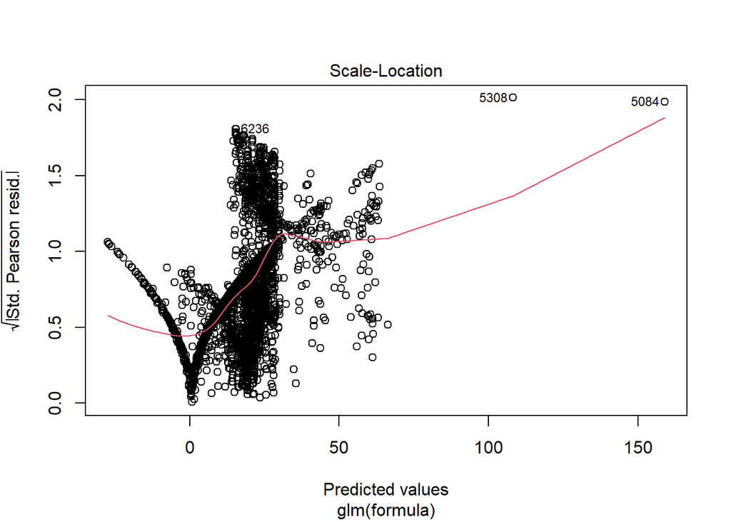

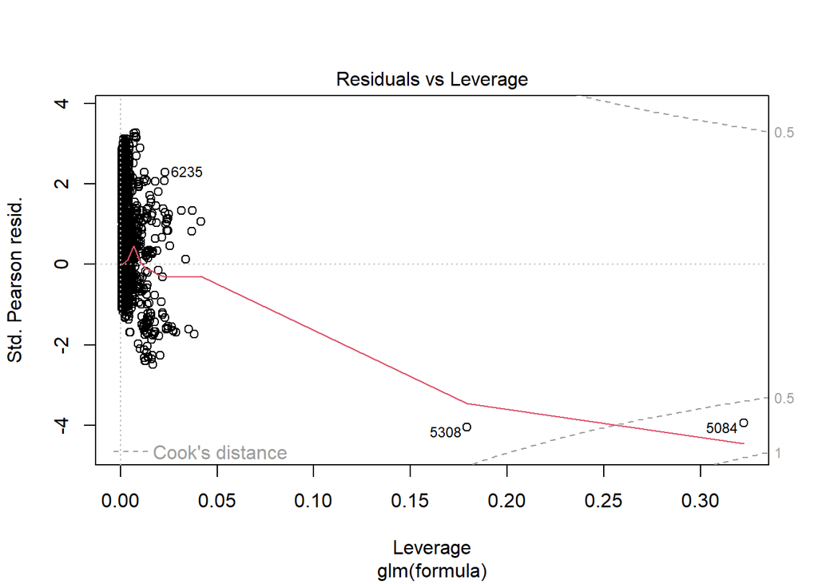

```r
# Plot diagnostics for the final model
plot(final_lm.fit)
```

```r
# introducing non-linear terms

# Add age_squared and weight_squared columns to train_data
train_data$age_squared <- train_data$age^2
train_data$weight_squared <- train_data$weight^2
test_data$age_squared <- test_data$age^2
test_data$weight_squared <- test_data$weight^2


# Number of folds for cross-validation
num_folds <- 5

# Create indices for cross-validation
cv_indices <- sample(1:num_folds, size = nrow(train_data), replace = TRUE)

# Initialize a vector to store cross-validated MSE values
cv_mse <- numeric(num_folds)

# Perform cross-validation
for (fold in 1:num_folds) {
  # Extract training and validation sets for the current fold
  train_data_cv <- train_data[cv_indices != fold, ]
  validation_data_cv <- train_data[cv_indices == fold, ]

  # Define the model formula
  formula <- calories ~ age + age_squared + gender + height + weight + weight_squared + steps + heart_rate + distance + resting_heart + intensity_karvonen + steps_times_distance

  # Fit the model on the training set with nonlinear terms
  lm.fit_cv <- glm(formula, data = train_data_cv)

  # Make predictions on the validation set
  predictions <- predict(lm.fit_cv, newdata = validation_data_cv)

  # Calculate MSE for the current fold
  cv_mse[fold] <- mean((validation_data_cv$calories - predictions)^2)
}

# Average MSE across folds
average_cv_mse <- mean(cv_mse)
cat("Average Cross-Validated MSE with Nonlinear Terms:", average_cv_mse, "\n")
```

```
## Average Cross-Validated MSE with Nonlinear Terms: 644.6449
```

```r
# Fit the model on the entire training set with nonlinear terms
final_lm_fit <- glm(calories ~ age + age_squared + gender + height + weight + weight_squared + steps + heart_rate + distance + resting_heart + intensity_karvonen + steps_times_distance, data = train_data)

# Make predictions on the test set
# Remove quadratic terms from both train_data and test_data before making predictions
train_data$age_squared <- NULL
train_data$weight_squared <- NULL

test_predictions <- predict(final_lm_fit, newdata = test_data)

test_data$age_squared <- NULL
test_data$weight_squared <- NULL

# Calculate test accuracy (MSE)
test_accuracy <- mean((test_data$calories - test_predictions)^2)
cat("Test Accuracy (MSE) on Test Data:", test_accuracy, "\n")
```

```
## Test Accuracy (MSE) on Test Data: 623.4117
```

```r
# Summary of the final model
summary(final_lm_fit)
```

```
##
## Call:
## glm(formula = calories ~ age + age_squared + gender + height +
##     weight + weight_squared + steps + heart_rate + distance +
##     resting_heart + intensity_karvonen + steps_times_distance,
##     data = train_data)
##
## Coefficients:
##                        Estimate Std. Error t value Pr(>|t|)
## (Intercept)           1.545e+01  1.594e+01   0.969 0.332355
## age                  -2.349e-01  2.879e-01  -0.816 0.414534
## age_squared           3.246e-03  4.069e-03   0.798 0.425135
## gender                3.984e+00  1.339e+00   2.977 0.002929 **
## height                9.472e-02  8.071e-02   1.174 0.240621
## weight               -1.550e-01  2.274e-01  -0.682 0.495577
## weight_squared       -1.213e-05  1.479e-03  -0.008 0.993454
## steps                -2.485e-02  1.835e-03 -13.544  < 2e-16 ***
## heart_rate            2.384e-01  5.031e-02   4.739 2.22e-06 ***
## distance              1.452e-01  1.148e-02  12.644  < 2e-16 ***
## resting_heart        -1.737e-01  4.534e-02  -3.832 0.000129 ***
## intensity_karvonen   -4.781e+01  6.387e+00  -7.484 8.64e-14 ***
## steps_times_distance -1.733e-04  1.265e-04  -1.371 0.170530
## ---
## Signif. codes:  0 '***' 0.001 '**' 0.01 '*' 0.05 '.' 0.1 ' ' 1
##
## (Dispersion parameter for gaussian family taken to be 635.5835)
##
##     Null deviance: 3274329  on 4383  degrees of freedom
## Residual deviance: 2778136  on 4371  degrees of freedom
## AIC: 40753
##
## Number of Fisher Scoring iterations: 2
```

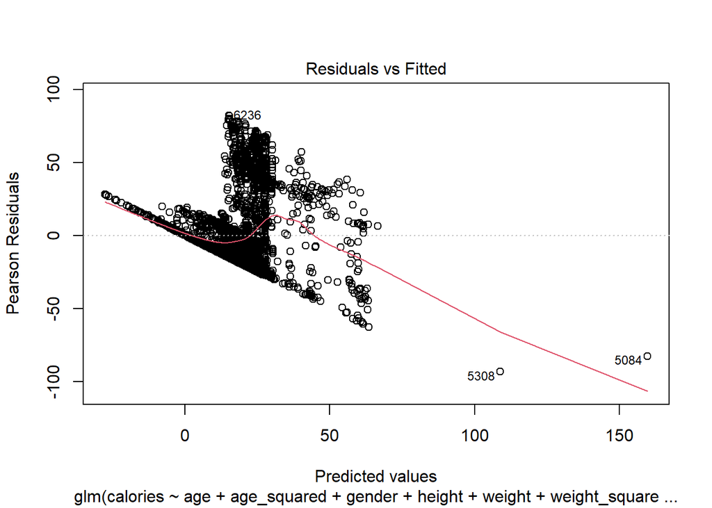

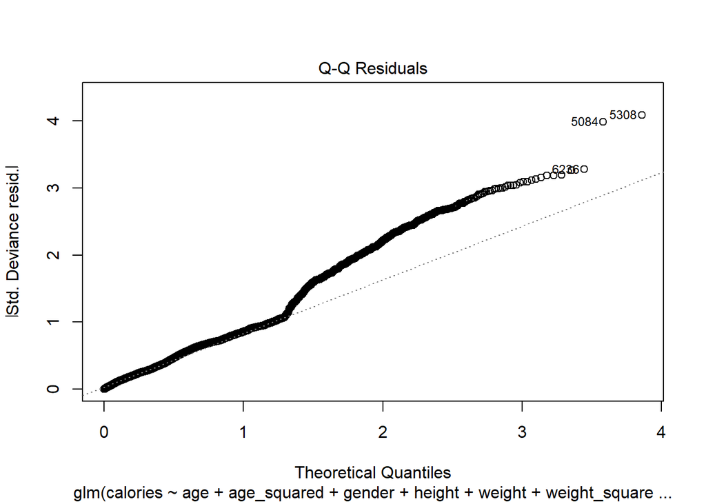

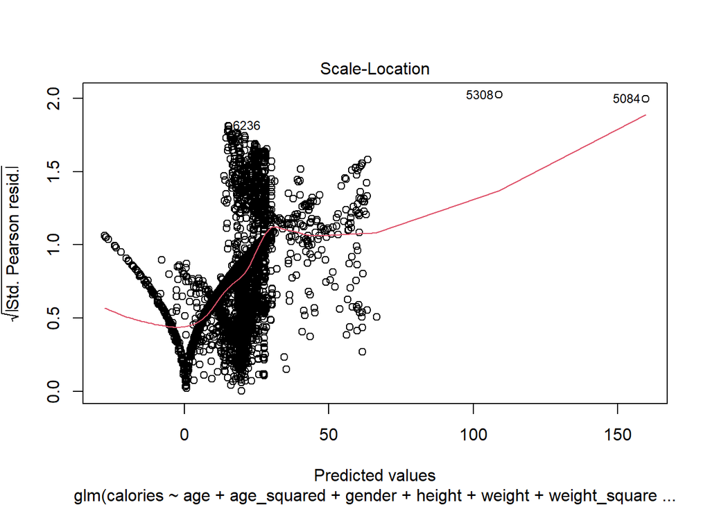

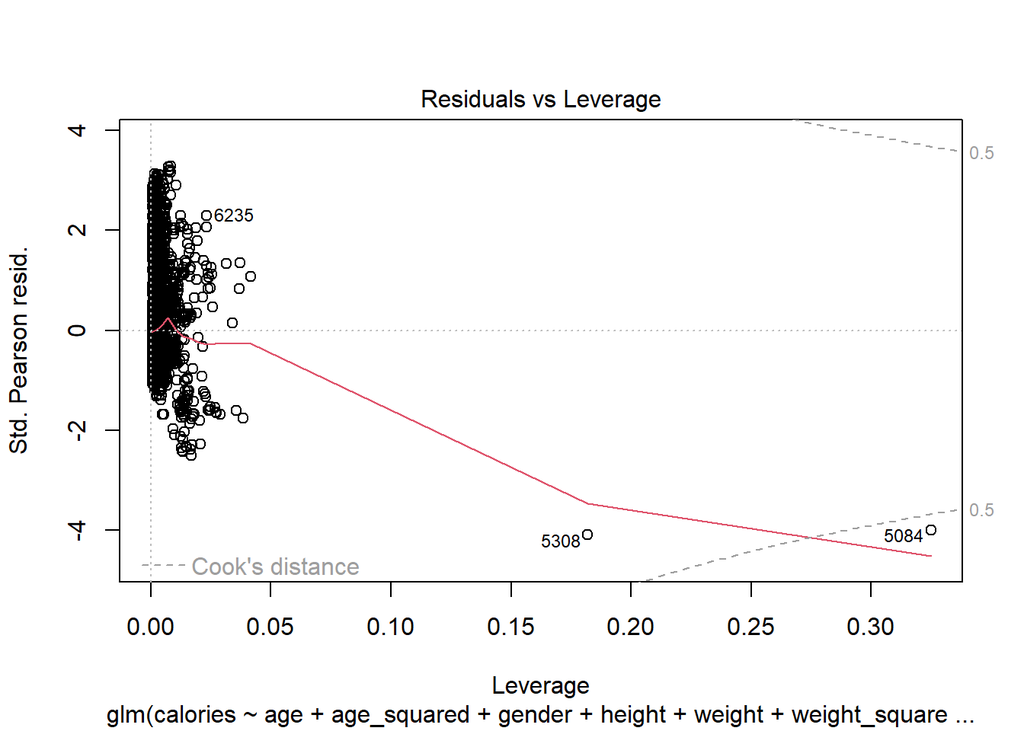

```r
# Plot diagnostics for the final model
plot(final_lm_fit)
```

**Observation:** Upon adding non-linear terms, the performance of the model did not improve. The MSE is 623.4117, indicating a poor fit. Additionally, the graphs do not show any indication of homoscedasticity.

## Ridge Regression

```r
# Extract predictor variables and response variable from the training data
train_data <- train_data[, !colnames(train_data) %in% c("age_squared", "weight_squared")]
X <- as.matrix(train_data[, -which(colnames(train_data) %in% "calories")])
y <- train_data$calories

# Standardize the predictor variables
X_standardized <- scale(X)

# Perform cross-validated ridge regression
cv_ridge_model <- cv.glmnet(X_standardized, y, alpha = 0)

# Optimal lambda from cross-validated ridge model
optimal_lambda <- cv_ridge_model$lambda.min

# Perform ridge regression using glmnet with the optimal lambda
ridge_model <- glmnet(X_standardized, y, alpha = 0, lambda = optimal_lambda)

# Extract coefficients for the optimal lambda
ridge_coefficients_optimal <- coef(ridge_model)

# Display the coefficients for the optimal lambda
print(ridge_coefficients_optimal)
```

```
## 11 x 1 sparse Matrix of class "dgCMatrix"
##                              s0
## (Intercept)          19.7138057
## age                  -0.3918388
## gender                2.1819478
## height                0.6747049
## weight               -2.0186067
## steps                -5.4100009
## heart_rate            3.1121871
## distance              6.5579874
## resting_heart        -1.4332256
## intensity_karvonen   -6.6793332
## steps_times_distance -0.3209129
```

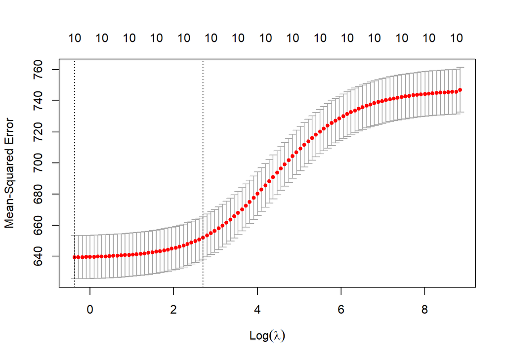

```r
plot(cv_ridge_model)
```

```r
response_variable <- "calories"

# Extract predictor variables and response variable from the test data
test_data <- test_data[, !colnames(test_data) %in% c("age_squared", "weight_squared")]
X_test <- as.matrix(test_data[, -which(colnames(test_data) %in% response_variable)])
y_test <- test_data[[response_variable]]

# Standardize the predictor variables using the mean and standard deviation from the training set
X_test_standardized <- scale(X_test, center = attr(X_standardized, "scaled:center"), scale = attr(X_standardized, "scaled:scale"))

# Make predictions on the test set
predictions <- predict(ridge_model, newx = X_test_standardized, s = optimal_lambda)

# Evaluate the performance of the model (e.g., using Mean Squared Error)
mse <- mean((predictions - y_test)^2)
print(mse)
```

```
## [1] 628.9871
```

**Observation:** Ridge regression introduces a regularization term, often denoted as λ (lambda), which is multiplied by the sum of the squared values of the coefficients. This regularization term, penalizes large coefficients and has a shrinking effect on the coefficients. As a result, it helps prevent overfitting by discouraging the model from fitting the noise in the training data.

After standardizing the variables (since Ridge regression penalizes the sum of squared coefficients, and having variables on different scales could lead to a situation where the penalty is dominated by variables with larger scales), we find the test MSE. However, the test MSE is very large (628.9871) indicating a poor fit of the model.

## The Lasso

```r
response_variable <- "calories"

# Extract predictor variables and response variable from the training data
train_data <- train_data[, !colnames(train_data) %in% c("age_squared", "weight_squared")]
X <- as.matrix(train_data[, -which(colnames(train_data) %in% response_variable)])
y <- train_data[[response_variable]]

# Reuse the standardized predictor variables from the ridge regression
X_standardized <- scale(X)

# Perform cross-validated Lasso regression
cv_lasso_model <- cv.glmnet(X_standardized, y, alpha = 1)  # Use alpha = 1 for Lasso

lasso_coefficients <- coef(cv_lasso_model)

print(lasso_coefficients)
```

```
## 11 x 1 sparse Matrix of class "dgCMatrix"
##                             s1
## (Intercept)          19.713806
## age                   .
## gender                .
## height                .
## weight                .
## steps                -4.134861
## heart_rate            .
## distance              4.524440
## resting_heart         .
## intensity_karvonen   -2.272192
## steps_times_distance  .
```

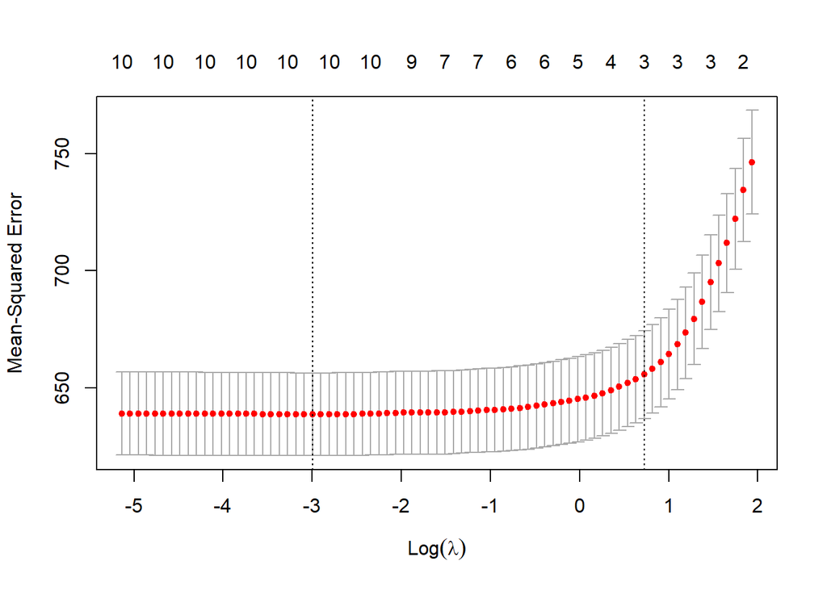

```r
# Plot the coefficient paths for different values of lambda
plot(cv_lasso_model)
```

```r
# Extract predictor variables and response variable from the test data
test_data <- test_data[, !colnames(test_data) %in% c("age_squared", "weight_squared")]
X_test <- as.matrix(test_data[, -which(colnames(test_data) %in% response_variable)])
y_test <- test_data[[response_variable]]

# Standardize the predictor variables using the mean and standard deviation from the training set
X_test_standardized <- scale(X_test, center = attr(X_standardized, "scaled:center"), scale = attr(X_standardized, "scaled:scale"))

# Make predictions on the test set
predictions <- predict(cv_lasso_model, newx = X_test_standardized, s = "lambda.min")  # "lambda.min" for the optimal lambda

# Evaluate the performance of the model (e.g., using Mean Squared Error)
mse <- mean((predictions - y_test)^2)
print(mse)
```

```
## [1] 626.2061
```

**Observation:** The Lasso induces sparsity in the model by forcing some coefficients to become exactly zero. Here, the coefficients for age, height, weight, heart_rate, resting_heart, and steps_times_distance have been set to zero. However, the MSE is equal to 626.2061 which is very high.

## SVM

```r
# Specify the response variable
response_variable <- "calories"

# Create a formula for the models
formula <- as.formula(paste(response_variable, "~ ."))

# Set up training control for cross-validation
ctrl <- trainControl(method = "cv", number = 5)  # 5-fold cross-validation

# Train Support Vector Machine (SVM) with Linear Kernel using cross-validation
svm_linear_model_cv <- train(formula, data = train_data, method = "svmLinear", trControl = ctrl)

# Print the summary of the cross-validated SVM with Linear Kernel model
print(svm_linear_model_cv)
```

```
## Support Vector Machines with Linear Kernel
##
## 4384 samples
##   10 predictor
##
## No pre-processing
## Resampling: Cross-Validated (5 fold)
## Summary of sample sizes: 3507, 3508, 3508, 3506, 3507
## Resampling results:
##
##   RMSE      Rsquared   MAE
##   27.30698  0.1087766  17.04412
##
## Tuning parameter 'C' was held constant at a value of 1
```

```r
# Make predictions on the test data using the cross-validated SVM with Linear Kernel model
predictions_svm_linear_cv <- predict(svm_linear_model_cv, test_data)

# Calculate Mean Squared Error (MSE) for SVM with Linear Kernel
mse_svm_linear_cv <- mean((test_data$calories - predictions_svm_linear_cv)^2)
print(paste("SVM with Linear Kernel - Mean Squared Error on Test Set (Cross-Validated):", mse_svm_linear_cv))
```

```
## [1] "SVM with Linear Kernel - Mean Squared Error on Test Set (Cross-Validated): 727.427659517388"
```

```r
# Train Support Vector Machine (SVM) with Radial Kernel using cross-validation
svm_radial_model_cv <- train(formula, data = train_data, method = "svmRadial", trControl = ctrl)

# Print the summary of the cross-validated SVM with Radial Kernel model
print(svm_radial_model_cv)
```

```
## Support Vector Machines with Radial Basis Function Kernel
##
## 4384 samples
##   10 predictor
##
## No pre-processing
## Resampling: Cross-Validated (5 fold)
## Summary of sample sizes: 3506, 3507, 3508, 3507, 3508
## Resampling results across tuning parameters:
##
##   C     RMSE      Rsquared   MAE
##   0.25  23.37905  0.3094366  14.73335
##   0.50  22.75756  0.3256673  14.33532
##   1.00  22.40037  0.3396574  14.04019
##
## Tuning parameter 'sigma' was held constant at a value of 0.1710827
## RMSE was used to select the optimal model using the smallest value.
## The final values used for the model were sigma = 0.1710827 and C = 1.
```

```r
# Make predictions on the test data using the cross-validated SVM with Radial Kernel model
predictions_svm_radial_cv <- predict(svm_radial_model_cv, test_data)

# Calculate Mean Squared Error (MSE) for SVM with Radial Kernel
mse_svm_radial_cv <- mean((test_data$calories - predictions_svm_radial_cv)^2)
print(paste("SVM with Radial Kernel - Mean Squared Error on Test Set (Cross-Validated):", mse_svm_radial_cv))
```

```
## [1] "SVM with Radial Kernel - Mean Squared Error on Test Set (Cross-Validated): 487.94932082189"
```

**Observation:** SVM regression performed poorly with MSE for linear and radial models having MSE value as 727.427 and 487.949. Here Radial model has performed better in comparison to ridge and lasso, but still this wouldn’t be a sufficient model to produce good results with SVM

## Random Forests

```r
#install.packages("caret")

# Specify the response variable
response_variable <- "calories"

# Create a formula for the random forest model
formula <- as.formula(paste(response_variable, "~ ."))

# Set up training control for cross-validation
ctrl <- trainControl(method = "cv", number = 5)  # 5-fold cross-validation

# Train the random forest model using cross-validation
rf_model_cv <- train(formula, data = train_data, method = "rf", trControl = ctrl)

# Print the summary of the cross-validated model
print(rf_model_cv)
```

```
## Random Forest
##
## 4384 samples
##   10 predictor
##
## No pre-processing
## Resampling: Cross-Validated (5 fold)
## Summary of sample sizes: 3506, 3507, 3508, 3508, 3507
## Resampling results across tuning parameters:
##
##   mtry  RMSE      Rsquared   MAE
##    2    14.97424  0.7009092  8.300568
##    6    14.82082  0.7057371  7.781877
##   10    14.84543  0.7047629  7.720795
##
## RMSE was used to select the optimal model using the smallest value.
## The final value used for the model was mtry = 6.
```

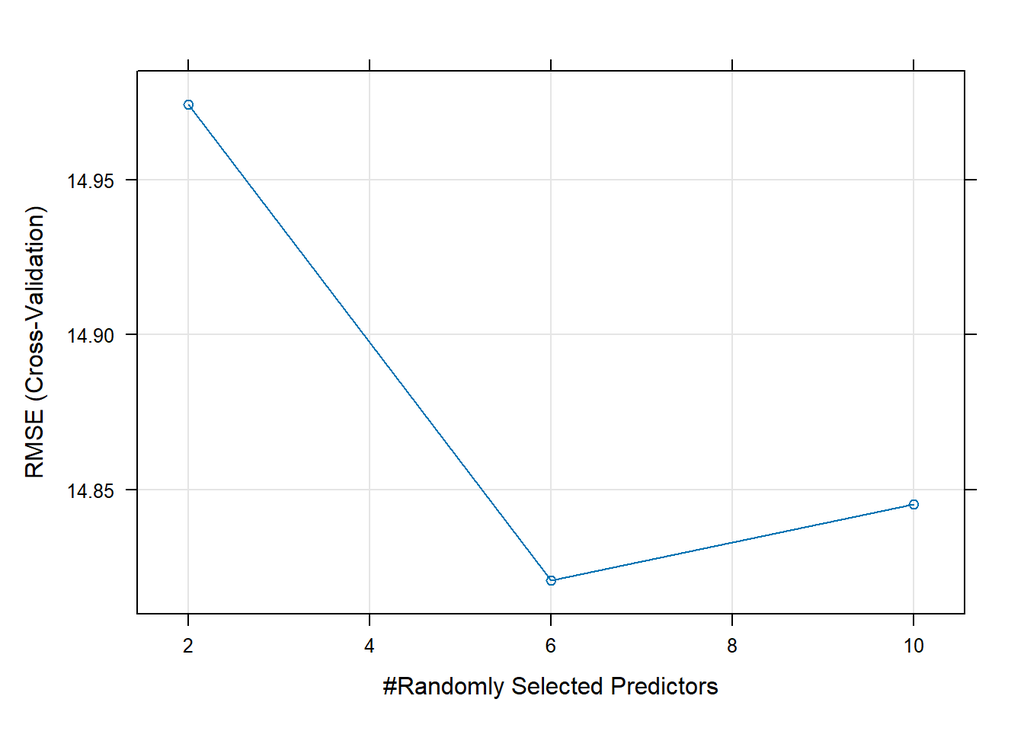

```r
plot(rf_model_cv)
```

```r
# Make predictions on the test data using the cross-validated model
predictions_cv <- predict(rf_model_cv, test_data)

# Calculate Mean Squared Error (MSE) or any other evaluation metric if needed
mse_cv <- mean((test_data$calories - predictions_cv)^2)
print(paste("Mean Squared Error on Test Set (Cross-Validated):", mse_cv))
```

```
## [1] "Mean Squared Error on Test Set (Cross-Validated): 200.968416435224"
```

## Gradient Boosting

```r
# Specify the response variable
response_variable <- "calories"

# Create a formula for the gradient boosting model
formula <- as.formula(paste(response_variable, "~ ."))

# Set up training control for cross-validation
ctrl <- trainControl(method = "cv", number = 5)  # 5-fold cross-validation

# Specify the tuning grid
tuning_grid <- expand.grid(
  n.trees = seq(100, 1000, by = 100),
  interaction.depth = seq(2, 10, by = 2),
  shrinkage = c(0.001, 0.01, 0.1),
  n.minobsinnode = c(5, 10, 20)
)

# Train the gradient boosting model using cross-validation
gbm_model_cv <- train(
  formula,
  data = train_data,
  method = "gbm",
  trControl = ctrl,
  tuneGrid = tuning_grid,
  verbose = FALSE
)

# Print the summary of the cross-validated model
print(gbm_model_cv)
```

```
## Stochastic Gradient Boosting
##
## 4384 samples
##   10 predictor
##
## No pre-processing
## Resampling: Cross-Validated (5 fold)
## Summary of sample sizes: 3507, 3506, 3508, 3507, 3508
## Resampling results across tuning parameters:
##
##   shrinkage  interaction.depth  n.minobsinnode  n.trees  RMSE      Rsquared
##   0.001       2                  5               100     26.35208  0.3953025
##   0.001       2                  5               200     25.52190  0.3964033
##   0.001       2                  5               300     24.81773  0.3976488
##   0.001       2                  5               400     24.22075  0.3990997
##   0.001       2                  5               500     23.71711  0.4003866
##   0.001       2                  5               600     23.29168  0.4020580
##   0.001       2                  5               700     22.93228  0.4040910
##   0.001       2                  5               800     22.62738  0.4064170
##   0.001       2                  5               900     22.36407  0.4090510
##   0.001       2                  5              1000     22.13816  0.4111700
##   0.001       2                 10               100     26.35303  0.3951759
##   0.001       2                 10               200     25.52342  0.3967783
##   0.001       2                 10               300     24.81854  0.3979063
##   0.001       2                 10               400     24.22096  0.3992060
##   0.001       2                 10               500     23.71673  0.4004745
##   0.001       2                 10               600     23.29115  0.4022185
##   0.001       2                 10               700     22.93076  0.4042033
##   0.001       2                 10               800     22.62769  0.4061315
##   0.001       2                 10               900     22.36543  0.4087393
##   0.001       2                 10              1000     22.13934  0.4113023
##   0.001       2                 20               100     26.35222  0.3947704
##   0.001       2                 20               200     25.52363  0.3953739
##   0.001       2                 20               300     24.81666  0.3970531
##   0.001       2                 20               400     24.21975  0.3985238
##   0.001       2                 20               500     23.71414  0.4002045
##   0.001       2                 20               600     23.29044  0.4019030
##   0.001       2                 20               700     22.93072  0.4039162
##   0.001       2                 20               800     22.62696  0.4060899
##   0.001       2                 20               900     22.36602  0.4085607
```

[output cut: 861 more lines]

```
##    9.405627
##   10.832889
##   10.409599
##   10.190369
##   10.079146
##    9.977998
##    9.890156
##    9.873187
##    9.779063
##    9.703327
##    9.673462
##
## RMSE was used to select the optimal model using the smallest value.
## The final values used for the model were n.trees = 1000, interaction.depth
##  = 10, shrinkage = 0.1 and n.minobsinnode = 10.
```

```r
# Make predictions on the test data using the cross-validated model
predictions_cv <- predict(gbm_model_cv, newdata = test_data, n.trees = gbm_model_cv$bestTune$n.trees)

# Calculate Mean Squared Error (MSE) or other evaluation metrics if needed
mse_cv <- mean((test_data$calories - predictions_cv)^2)
print(paste("Mean Squared Error on Test Set (Cross-Validated):", mse_cv))
```

```
## [1] "Mean Squared Error on Test Set (Cross-Validated): 233.560871537828"
```

**Observation** : Test MSE of 233.56 which is still a poor performance for calorie prediction. From the EDA, three of the activities had large amount of outliers. So we have dropped those activity rows and performed regression analysis (Separate markdown file) to see if that would benefit having better accuracy in calorie prediction.

Inferences and comparisons of all models are added in the Project report.

# 2. Classification

```r
### cleaning the data
columns_to_drop <- c("X1", "X", "device", "entropy_heart", "entropy_setps", "corr_heart_steps", "norm_heart", "sd_norm_heart")
aw_fb_data_class <- aw_fb_data[, !(names(aw_fb_data) %in% columns_to_drop)]

colnames(aw_fb_data_class)[colnames(aw_fb_data_class) == "hear_rate"] <- "heart_rate"

index <- createDataPartition(aw_fb_data_class$activity, p = 0.8, list = FALSE)
aw_fb_data_class <- aw_fb_data_class[index, ]
test_data <- aw_fb_data_class[-index, ]  # Hold-out test set

head(aw_fb_data_class)
```

```
##   age gender height weight    steps heart_rate   calories    distance
## 1  20      1    168   65.4 10.77143   78.53130  0.3445329 0.008326857
## 2  20      1    168   65.4 11.47532   78.45339  3.2876255 0.008896346
## 4  20      1    168   65.4 12.88312   78.62826 10.1545556 0.010035325
## 5  20      1    168   65.4 13.58701   78.71569 10.8251111 0.010604814
## 6  20      1    168   65.4 14.29091   78.80313 11.4956667 0.011174303
## 7  20      1    168   65.4 14.99481   78.89056 12.1662222 0.011743792
##   resting_heart intensity_karvonen steps_times_distance activity
## 1            59          0.1385199           0.08969215    Lying
## 2            59          0.1379673           0.10208846    Lying
## 4            59          0.1392075           0.12928626    Lying
## 5            59          0.1398276           0.14408774    Lying
## 6            59          0.1404477           0.15969095  Sitting
## 7            59          0.1410678           0.17609588  Sitting
```

## Logistic Regression

```r
# Convert the "activity" variable to a factor with custom levels
aw_fb_data_class$activity <- factor(aw_fb_data_class$activity, levels = c('Lying', 'Running 3 METs', 'Running 5 METs', 'Running 7 METs', 'Self Pace walk', 'Sitting'))
test_data$activity <- factor(test_data$activity, levels = c('Lying', 'Running 3 METs', 'Running 5 METs', 'Running 7 METs', 'Self Pace walk', 'Sitting'))

# Define the control parameters for cross-validation
ctrl <- trainControl(method = "cv",  # Cross-validation method
                     number = 5)     # Number of folds (you can change this number)

# Fit a multinomial logistic regression model using k-fold cross-validation
multinom_model <- train(activity ~ age + gender + height + weight + steps + heart_rate + distance + resting_heart + intensity_karvonen + steps_times_distance,
                        data = aw_fb_data_class,
                        method = "multinom",
                        trControl = ctrl)
# Get cross-validated accuracy
cv_accuracy <- multinom_model$results$Accuracy[1]  # Extract cross-validated accuracy
print(paste("Cross-Validated Accuracy:", cv_accuracy))
```

```
## [1] "Cross-Validated Accuracy: 0.268845084138365"
```

```r
# Get predictions on the test set for each fold
predictions <- predict(multinom_model, newdata = test_data)

# Calculate accuracy using confusionMatrix function
accuracy <- confusionMatrix(predictions, test_data$activity)$overall['Accuracy']
print(paste("Accuracy on Test Set:", accuracy))
```

```
## [1] "Accuracy on Test Set: 0.247761194029851"
```

```r
# Print Confusion Matrix
confusion_matrix <- confusionMatrix(predictions, test_data$activity)
print(confusion_matrix)
```

```
## Confusion Matrix and Statistics
##
##                 Reference
## Prediction       Lying Running 3 METs Running 5 METs Running 7 METs
##   Lying            176             97            100            111
##   Running 3 METs     1              3              0              2
##   Running 5 METs     5              6              4              0
##   Running 7 METs    22             28             73             63
##   Self Pace walk     2              0              1              0
##   Sitting            3              2              2              1
##                 Reference
## Prediction       Self Pace walk Sitting
##   Lying                     124     127
##   Running 3 METs              0       0
##   Running 5 METs              2       2
##   Running 7 METs             17      24
##   Self Pace walk              1       0
##   Sitting                     4       2
##
## Overall Statistics
##
##                Accuracy : 0.2478
##                  95% CI : (0.2213, 0.2757)
##     No Information Rate : 0.208
##     P-Value [Acc > NIR] : 0.001298
##
##                   Kappa : 0.0611
##
##  Mcnemar's Test P-Value : NA
##
## Statistics by Class:
##
##                      Class: Lying Class: Running 3 METs Class: Running 5 METs
## Sensitivity                0.8421              0.022059               0.02222
## Specificity                0.2977              0.996548               0.98182
## Pos Pred Value             0.2395              0.500000               0.21053
## Neg Pred Value             0.8778              0.866867               0.82150
## Prevalence                 0.2080              0.135323               0.17910
## Detection Rate             0.1751              0.002985               0.00398
## Detection Prevalence       0.7313              0.005970               0.01891
## Balanced Accuracy          0.5699              0.509303               0.50202
##                      Class: Running 7 METs Class: Self Pace walk Class: Sitting
## Sensitivity                        0.35593              0.006757        0.01290
## Specificity                        0.80193              0.996499        0.98588
## Pos Pred Value                     0.27753              0.250000        0.14286
## Neg Pred Value                     0.85347              0.853147        0.84561
## Prevalence                         0.17612              0.147264        0.15423
## Detection Rate                     0.06269              0.000995        0.00199
## Detection Prevalence               0.22587              0.003980        0.01393
## Balanced Accuracy                  0.57893              0.501628        0.49939
```

**Observation:** Accuracy from cross-validation is approximately 26.88 %, indicating the average squared difference between predicted values and actual values on the test set. This signifies the model’s predictive accuracy, with lower values suggesting better performance.

The accuracy on the test set is approximately 24.77 %. This means that the model correctly predicted the activity roughly 24.77% of the time, which indicates the proportion of correct predictions made by the model among all predictions on the test set. There might be complexities in the data that the model hasn’t fully captured or other factors impacting prediction quality.

## Naive Bayes

```r
# Convert the "activity" variable to a factor with custom levels
aw_fb_data_class$activity <- factor(aw_fb_data_class$activity, levels = c('Lying', 'Running 3 METs', 'Running 5 METs', 'Running 7 METs', 'Self Pace walk', 'Sitting'))
test_data$activity <- factor(test_data$activity, levels = c('Lying', 'Running 3 METs', 'Running 5 METs', 'Running 7 METs', 'Self Pace walk', 'Sitting'))

# Perform k-fold cross-validation
ctrl <- trainControl(method = "cv", number = 5)  # 5-fold cross-validation
nb_model_cv <- train(activity ~ age + gender + height + weight + steps + heart_rate + distance + resting_heart + intensity_karvonen + steps_times_distance,
                     data = aw_fb_data_class,
                     method = "naive_bayes",
                     trControl = ctrl)

# Get cross-validated accuracy
cv_accuracy <- nb_model_cv$results$Accuracy[1]  # Extract cross-validated accuracy
print(paste("Cross-Validated Accuracy:", cv_accuracy))
```

```
## [1] "Cross-Validated Accuracy: 0.281219436960381"
```

```r
# Get predictions on the test set from the cross-validated model
predictions <- predict(nb_model_cv, newdata = test_data)

# Calculate accuracy
accuracy <- mean(predictions == test_data$activity)
print(paste("Accuracy on Test Set:", accuracy))
```

```
## [1] "Accuracy on Test Set: 0.335323383084577"
```

```r
# Print Confusion Matrix
confusion_matrix <- confusionMatrix(predictions, test_data$activity)
print(confusion_matrix)
```

```
## Confusion Matrix and Statistics
##
##                 Reference
## Prediction       Lying Running 3 METs Running 5 METs Running 7 METs
##   Lying            129             55             65             75
##   Running 3 METs     9             28             10              7
##   Running 5 METs     7             14             56             16
##   Running 7 METs    45             15             38             69
##   Self Pace walk    12             21             10              6
##   Sitting            7              3              1              4
##                 Reference
## Prediction       Self Pace walk Sitting
##   Lying                      74      74
##   Running 3 METs             13       3
##   Running 5 METs              3       9
##   Running 7 METs             14      43
##   Self Pace walk             42      13
##   Sitting                     2      13
##
## Overall Statistics
##
##                Accuracy : 0.3353
##                  95% CI : (0.3062, 0.3655)
##     No Information Rate : 0.208
##     P-Value [Acc > NIR] : < 2.2e-16
##
##                   Kappa : 0.1845
##
##  Mcnemar's Test P-Value : < 2.2e-16
##
## Statistics by Class:
##
##                      Class: Lying Class: Running 3 METs Class: Running 5 METs
## Sensitivity                0.6172               0.20588               0.31111
## Specificity                0.5691               0.95167               0.94061
## Pos Pred Value             0.2733               0.40000               0.53333
## Neg Pred Value             0.8499               0.88449               0.86222
## Prevalence                 0.2080               0.13532               0.17910
## Detection Rate             0.1284               0.02786               0.05572
## Detection Prevalence       0.4697               0.06965               0.10448
## Balanced Accuracy          0.5932               0.57878               0.62586
##                      Class: Running 7 METs Class: Self Pace walk Class: Sitting
## Sensitivity                        0.38983               0.28378        0.08387
## Specificity                        0.81280               0.92765        0.98000
## Pos Pred Value                     0.30804               0.40385        0.43333
## Neg Pred Value                     0.86172               0.88235        0.85436
## Prevalence                         0.17612               0.14726        0.15423
## Detection Rate                     0.06866               0.04179        0.01294
## Detection Prevalence               0.22289               0.10348        0.02985
## Balanced Accuracy                  0.60132               0.60572        0.53194
```

## KNN

```r
library(reshape2)
library(ggplot2)

# Initialize empty vectors to store accuracies
k_values <- 1:10
test_accuracies <- rep(NA, 10)
cv_accuracies <- rep(NA, 10)
confusion_matrices <- list()

# Loop through different k values and compute accuracies and confusion matrices
for (k in k_values) {
  ctrl <- trainControl(method = "cv", number = 5)
  knn_model_cv <- train(activity ~ age + gender + height + weight + steps + heart_rate + distance + resting_heart + intensity_karvonen + steps_times_distance,
                        data = aw_fb_data_class,
                        method = "knn",
                        trControl = ctrl,
                        tuneGrid = data.frame(k = k))

  predictions <- predict(knn_model_cv, newdata = test_data)

  cv_accuracy <- knn_model_cv$results$Accuracy[1]
  cv_accuracies[k] <- cv_accuracy

  accuracy <- mean(predictions == test_data$activity)
  test_accuracies[k] <- accuracy

  confusion_matrices[[as.character(k)]] <- confusionMatrix(data = factor(predictions, levels = levels(test_data$activity)),
                                                           reference = factor(test_data$activity, levels = levels(test_data$activity)))
}

# Create a data frame with k values and accuracies
accuracy_df <- data.frame(k_values, test_accuracies, cv_accuracies)

# Melt the data for plotting
accuracy_melted <- melt(accuracy_df, id.vars = "k_values", variable.name = "Accuracy_Type", value.name = "Accuracy")

# Plot the accuracies
accuracy_plot <- ggplot(accuracy_melted, aes(x = factor(k_values), y = Accuracy, color = Accuracy_Type)) +
  geom_line() +
  geom_point() +
  labs(x = "k values", y = "Accuracy", color = "Accuracy Type") +
  ggtitle("Test Accuracy and Cross-Validated Accuracy for different k values in KNN") +
  theme_minimal()

# Display confusion matrices for each k value
for (i in seq_along(k_values)) {
  print(paste("Confusion Matrix for k =", k_values[i]))
  print(as.matrix(confusion_matrices[[as.character(k_values[i])]]$table))
  print("----------------------------")
}
```

```
## [1] "Confusion Matrix for k = 1"
##                 Reference
## Prediction       Lying Running 3 METs Running 5 METs Running 7 METs
##   Lying            205              0              0              2
##   Running 3 METs     0            136              0              0
##   Running 5 METs     0              0            179              0
##   Running 7 METs     4              0              1            175
##   Self Pace walk     0              0              0              0
##   Sitting            0              0              0              0
##                 Reference
## Prediction       Self Pace walk Sitting
##   Lying                       1       0
##   Running 3 METs              0       0
##   Running 5 METs              0       1
##   Running 7 METs              0       0
##   Self Pace walk            147       0
##   Sitting                     0     154
## [1] "----------------------------"
## [1] "Confusion Matrix for k = 2"
##                 Reference
## Prediction       Lying Running 3 METs Running 5 METs Running 7 METs
##   Lying            163              5              7             11
##   Running 3 METs     9            124              2              1
##   Running 5 METs     8              2            149              7
##   Running 7 METs    12              0              9            151
##   Self Pace walk     8              5              6              0
##   Sitting            9              0              7              7
##                 Reference
## Prediction       Self Pace walk Sitting
##   Lying                       5      13
##   Running 3 METs              3       1
##   Running 5 METs              3       8
##   Running 7 METs              2       6
##   Self Pace walk            130       7
##   Sitting                     5     120
## [1] "----------------------------"
## [1] "Confusion Matrix for k = 3"
##                 Reference
## Prediction       Lying Running 3 METs Running 5 METs Running 7 METs
##   Lying            163              5              5             11
```

[output cut: 125 more lines]

```
##   Lying            133             10             12             12
##   Running 3 METs    17            108              6              5
##   Running 5 METs     6              5            137             14
##   Running 7 METs    15              0             10            131
##   Self Pace walk    17              9              5              3
##   Sitting           21              4             10             12
##                 Reference
## Prediction       Self Pace walk Sitting
##   Lying                       8      25
##   Running 3 METs              5       3
##   Running 5 METs              4       9
##   Running 7 METs              3      15
##   Self Pace walk            119      14
##   Sitting                     9      89
## [1] "----------------------------"
```

```
## `geom_line()`: Each group consists of only one observation.
## ℹ Do you need to adjust the group aesthetic?
```

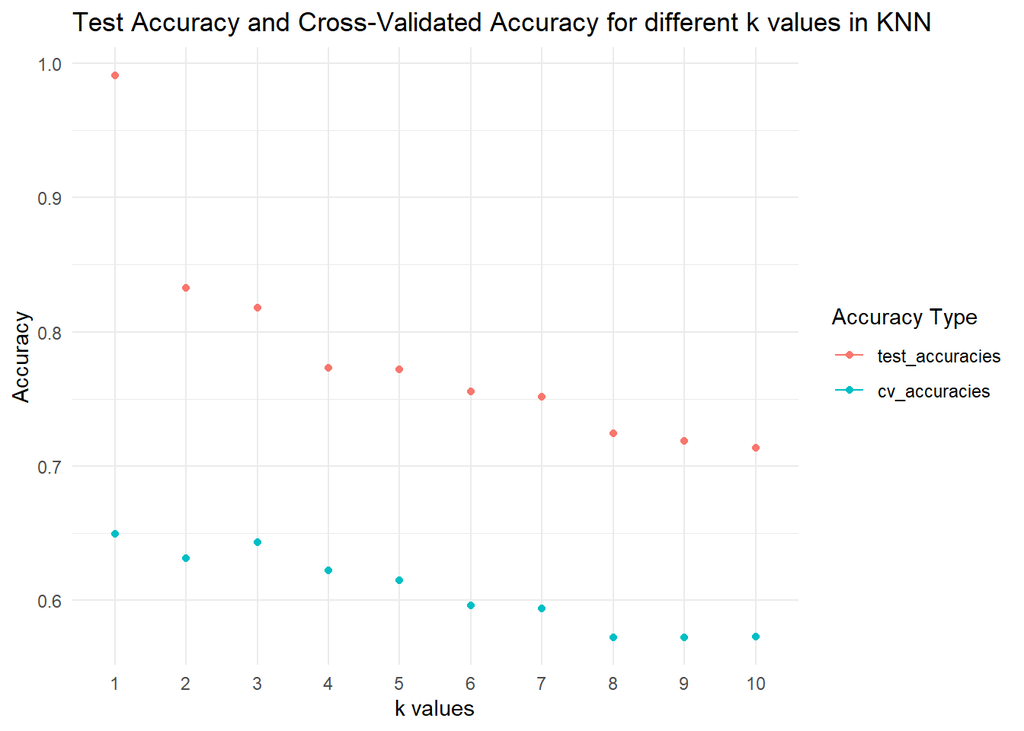

```r
# Display the plot
print(accuracy_plot)
```

```r
# Create a data frame with k values, test accuracies, and cross-validated accuracies
accuracy_table <- data.frame(K = k_values, CV_Accuracy = cv_accuracies, Test_Accuracy = test_accuracies)

# Print the table
print(accuracy_table)
```

```
##     K CV_Accuracy Test_Accuracy
## 1   1   0.6493786     0.9910448
## 2   2   0.6310327     0.8328358
## 3   3   0.6432004     0.8179104
## 4   4   0.6220525     0.7731343
## 5   5   0.6146787     0.7721393
## 6   6   0.5963330     0.7552239
## 7   7   0.5939301     0.7512438
## 8   8   0.5725794     0.7243781
## 9   9   0.5725895     0.7184080
## 10 10   0.5729919     0.7134328
```

**Observation:** For k values 1,2 and 3 have higher accuracies, one could prefer to have k values as less as possible but it could lead to overfitting and the unseen dataset if used it might not perform well. Here test split would have had similar pattern from the train set but if we switch devices and provide that data it might not perform well due to overfitting. So considering other K values 4 and 5 gives a better output overall and comparatively the accuracies or same level from KNN = 4 to 7. So somewhere between these 4 to 7 would generalize the model better and perform well in this case as we can from PCA it was evident the data obtained from smart wearbles are indeed non linear and have complex structure in reduced dimensions.

## SVM

```r
# Convert the "activity" variable to a factor with custom levels
aw_fb_data_class$activity <- factor(aw_fb_data_class$activity, levels = c('Lying', 'Running 3 METs', 'Running 5 METs', 'Running 7 METs', 'Self Pace walk', 'Sitting'))
test_data$activity <- factor(test_data$activity, levels = c('Lying', 'Running 3 METs', 'Running 5 METs', 'Running 7 METs', 'Self Pace walk', 'Sitting'))

# Perform k-fold cross-validation for radial SVM
svm_model_radial <- train(activity ~ ., data = aw_fb_data_class,
                          method = "svmRadial",
                          trControl = trainControl(method = "cv", number = 5),
                          preProcess = c("center", "scale"))

# Print radial SVM results
print("SVM Radial Kernel - Cross-validation results:")
```

```
## [1] "SVM Radial Kernel - Cross-validation results:"
```

```r
print(svm_model_radial)
```

```
## Support Vector Machines with Radial Basis Function Kernel
##
## 5014 samples
##   11 predictor
##    6 classes: 'Lying', 'Running 3 METs', 'Running 5 METs', 'Running 7 METs', 'Self Pace walk', 'Sitting'
##
## Pre-processing: centered (11), scaled (11)
## Resampling: Cross-Validated (5 fold)
## Summary of sample sizes: 4011, 4011, 4012, 4011, 4011
## Resampling results across tuning parameters:
##
##   C     Accuracy   Kappa
##   0.25  0.3699638  0.2174606
##   0.50  0.3875131  0.2410969
##   1.00  0.4048654  0.2648186
##
## Tuning parameter 'sigma' was held constant at a value of 0.1299881
## Accuracy was used to select the optimal model using the largest value.
## The final values used for the model were sigma = 0.1299881 and C = 1.
```

```r
# Perform k-fold cross-validation for linear SVM
svm_model_linear <- train(activity ~ ., data = aw_fb_data_class,
                          method = "svmLinear",
                          trControl = trainControl(method = "cv", number = 5),
                          preProcess = c("center", "scale"))

# Print linear SVM results
print("SVM Linear Kernel - Cross-validation results:")
```

```
## [1] "SVM Linear Kernel - Cross-validation results:"
```

```r
print(svm_model_linear)
```

```
## Support Vector Machines with Linear Kernel
##
## 5014 samples
##   11 predictor
##    6 classes: 'Lying', 'Running 3 METs', 'Running 5 METs', 'Running 7 METs', 'Self Pace walk', 'Sitting'
##
## Pre-processing: centered (11), scaled (11)
## Resampling: Cross-Validated (5 fold)
## Summary of sample sizes: 4011, 4013, 4010, 4013, 4009
## Resampling results:
##
##   Accuracy   Kappa
##   0.3145213  0.145519
##
## Tuning parameter 'C' was held constant at a value of 1
```

```r
 # Predict on test data using the trained models
predictions_radial <- predict(svm_model_radial, newdata = test_data)
predictions_linear <- predict(svm_model_linear, newdata = test_data)

# Calculate accuracy for radial SVM
accuracy_radial <- confusionMatrix(predictions_radial, test_data$activity)$overall['Accuracy']
cat("SVM Radial Kernel - Accuracy on Test Data:", accuracy_radial, "\n")
```

```
## SVM Radial Kernel - Accuracy on Test Data: 0.4527363
```

```r
# Calculate accuracy for linear SVM
accuracy_linear <- confusionMatrix(predictions_linear, test_data$activity)$overall['Accuracy']
cat("SVM Linear Kernel - Accuracy on Test Data:", accuracy_linear, "\n")
```

```
## SVM Linear Kernel - Accuracy on Test Data: 0.2925373
```

## Random forest with multiple trees :

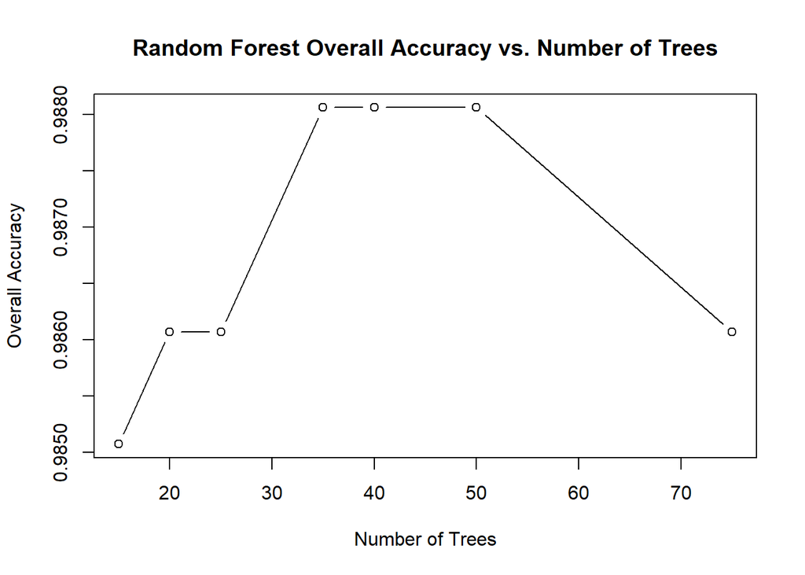

```r
# Assuming 'aw_fb_data_class' contains your dataset

# Convert 'activity' column to factor (if not already)
aw_fb_data_class$activity <- factor(aw_fb_data_class$activity, levels = c('Lying', 'Running 3 METs', 'Running 5 METs', 'Running 7 METs', 'Self Pace walk', 'Sitting'))
test_data$activity <- factor(test_data$activity, levels = c('Lying', 'Running 3 METs', 'Running 5 METs', 'Running 7 METs', 'Self Pace walk', 'Sitting'))

# Define an array of numbers of trees to test
num_trees_array <- c(15, 20, 25, 35, 40, 50, 75)

# Create empty matrices to store accuracies for each class and overall accuracy
class_accuracies <- matrix(0, nrow = length(num_trees_array), ncol = 6)  # 6 classes
overall_accuracies <- numeric(length(num_trees_array))

# Perform analysis for each number of trees
for (i in 1:length(num_trees_array)) {
  num_trees <- num_trees_array[i]

  # Fit a random forest model on the full dataset
  rf_model <- randomForest(activity ~ age + gender + height + weight + steps + heart_rate + distance + resting_heart + intensity_karvonen + steps_times_distance,
                           data = aw_fb_data_class,
                           ntree = num_trees,
                           keep.forest = TRUE)

  # Use the trained Random Forest model to make predictions on the test dataset
  test_predictions <- predict(rf_model, newdata = test_data)

  # Calculate overall accuracy
  overall_accuracy <- mean(test_predictions == test_data$activity)
  overall_accuracies[i] <- overall_accuracy

  # Create confusion matrix to calculate class-wise accuracies
  confusion_mat <- table(test_predictions, test_data$activity)
  class_accuracy <- diag(confusion_mat) / rowSums(confusion_mat)
  class_accuracies[i, ] <- ifelse(is.na(class_accuracy), 0, class_accuracy)
}

# Plotting overall accuracy for each number of trees
plot(num_trees_array, overall_accuracies, type = 'b',
     xlab = "Number of Trees", ylab = "Overall Accuracy",
     main = "Random Forest Overall Accuracy vs. Number of Trees")
```

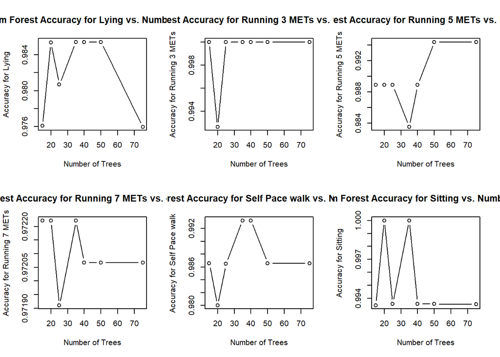

```r
# Plotting class-wise accuracy for each class and each number of trees
par(mfrow = c(2, 3))  # Setting up the layout for multiple plots
classes <- c('Lying', 'Running 3 METs', 'Running 5 METs', 'Running 7 METs', 'Self Pace walk', 'Sitting')
for (j in 1:6) {
  plot(num_trees_array, class_accuracies[, j], type = 'b',
       xlab = "Number of Trees", ylab = paste("Accuracy for", classes[j]),
       main = paste("Random Forest Accuracy for", classes[j], "vs. Number of Trees"))
}
```

```r
for (i in 1:length(num_trees_array)) {
  cat("Number of Trees:", num_trees_array[i], "\tOverall Accuracy:", overall_accuracies[i], "\n")
}
```

```
## Number of Trees: 15  Overall Accuracy: 0.9850746
## Number of Trees: 20  Overall Accuracy: 0.9860697
## Number of Trees: 25  Overall Accuracy: 0.9860697
## Number of Trees: 35  Overall Accuracy: 0.9880597
## Number of Trees: 40  Overall Accuracy: 0.9880597
## Number of Trees: 50  Overall Accuracy: 0.9880597
## Number of Trees: 75  Overall Accuracy: 0.9860697
```